```python
%load_ext autoreload
%autoreload 2
```

# Assignment 2: Designing an Architecture for Recognizing UVA Historical Landmarks

[figure not shown]

The UVA Grounds is known for its Jeffersonian architecture and place in U.S. history as a model for college and university campuses throughout the country. Throughout its history, the University of Virginia has been praised for its unique Jeffersonian architecture.

In this assignment, you will attempt the build an image recognition system to classify different buildlings/landmarks on Grounds. You will earn 150 points for this assignment if you successfully transfer at least 3 existing architectures, plus 10 bonus points if your classifier performance exceeds 94% accuracy.

To make it easier for you, some codes have been provided to help you process the data, you may modify it to fit your needs. You must submit the .ipynb file via UVA Canvas with the following format: yourcomputingID_assignment_2.ipynb

Best of luck, and have fun!

## TA's notes

Requirements:

- You must be able to implement a complete training/validation loop with a final test. The basic logic is similar to the FashionMNIST in previous tutorials.
- You must use 3 models. You could create/train all models from scratch or you can use transfer learning (for example, torchvision.models.resnet18) for one, two, or all of them. You may find CNN-specific architectures (e.g., LeNet, AlexNet, ResNet variants, GoogLeNet, VGG, etc) will be helpful. The most widely used CNN architectures include VGG-16 and ResNet-FPN-X101 (but they may be too big for Google Colab GPUs, so try small variants if that's the case). You could also try state-of-the-art Vision Transformers (ViT) but it's technically not a CNN so the rest of your models must both be CNN. ViTs might also be too big for the Google Colab GPUs. The above-mentioned architectures all have pretrained versions in [torchvision](https://pytorch.org/vision/stable/models.html).
- You can use the Sequential model creation instead of the class API, but that can make adding/changing various modules more difficult.
- Please split your own validation set. We've done this in previous tutorials also.
- Please do NOT change the random `SEED` or the test dataset/dataloader so I can verify your performance.
- Please also plot your training and loss curves. This way you and I will both understand the learning process and identify any problem.
- Please make your 3 models sufficiently different. For example, it's not enough to add one layer and call that a different model.

# Load Packages

```python
import sys
import sklearn
import os
import numpy as np
import matplotlib as mpl
import matplotlib.pyplot as plt
from functools import partial
import PIL
import PIL.Image

import torch
```

# Random Seed for Reproduction

```python
from torch import manual_seed as torch_manual_seed
import random
import numpy as np

from torch.cuda import max_memory_allocated, set_device, manual_seed_all
from torch.backends import cudnn

def setup_seed(seed):
    torch_manual_seed(seed)
    manual_seed_all(seed)
    np.random.seed(seed)
    random.seed(seed)
    cudnn.deterministic = True

SEED = 42
setup_seed(SEED)
```

# Import Dataset

The full dataset is huge (+37GB) with +13K images of 18 classes. So it will take a while to download, extract, and process. To save you time and effort, a subset of the data has been resized and compressed to only 379Mb and stored in a Firebase server. This dataset will be the one you will benchmark for your grade. If you are up for a challenge (and perhaps bonus points), contact the instructor for the full dataset!

```python
# Download dataset from FirebaseStorage
!curl -L "https://firebasestorage.googleapis.com/v0/b/uva-landmark-images.appspot.com/o/dataset.zip?alt=media&token=e1403951-30d6-42b8-ba4e-394af1a2ddb7" -o "dataset.zip"
```

```
  % Total    % Received % Xferd  Average Speed   Time    Time     Time  Current
                                 Dload  Upload   Total   Spent    Left  Speed
100  378M  100  378M    0     0   125M      0  0:00:03  0:00:03 --:--:--  125M
```

```python
# Extract content
!unzip -q "dataset.zip"
```

```python
from sklearn.datasets import load_files

data_dir = "dataset/"
batch_size = 32;
# IMPORTANT: Depends on what pre-trained model you choose, you will need to change these dimensions accordingly
img_height = 150;
img_width = 150;
```

```python
from torch.utils.data import DataLoader, random_split
from torch import Generator
from torchvision.transforms import ToTensor
from torchvision.datasets import ImageFolder


TEST_RATIO = 0.2
BATCH_SIZE = 32

# Download and load the training data
dataset_all = ImageFolder(
    data_dir,
    transform=ToTensor(),
)

size_all = len(dataset_all)
print(f'Before splitting the full dataset into train and test: len(dataset_all)={size_all}')


size_test = int(size_all * TEST_RATIO)
size_train = size_all - size_test

dataset_train, dataset_test = random_split(dataset_all, [size_train, size_test], generator=Generator().manual_seed(SEED))
print(f'After splitting the full dataset into train and test: len(dataset_train)={len(dataset_train)}. len(dataset_test)={len(dataset_test)}')

# NOTE that you must not use the test dataset for model selection
```

```
Before splitting the full dataset into train and test: len(dataset_all)=14286
After splitting the full dataset into train and test: len(dataset_train)=11429. len(dataset_test)=2857
```

```
num classes 18
```

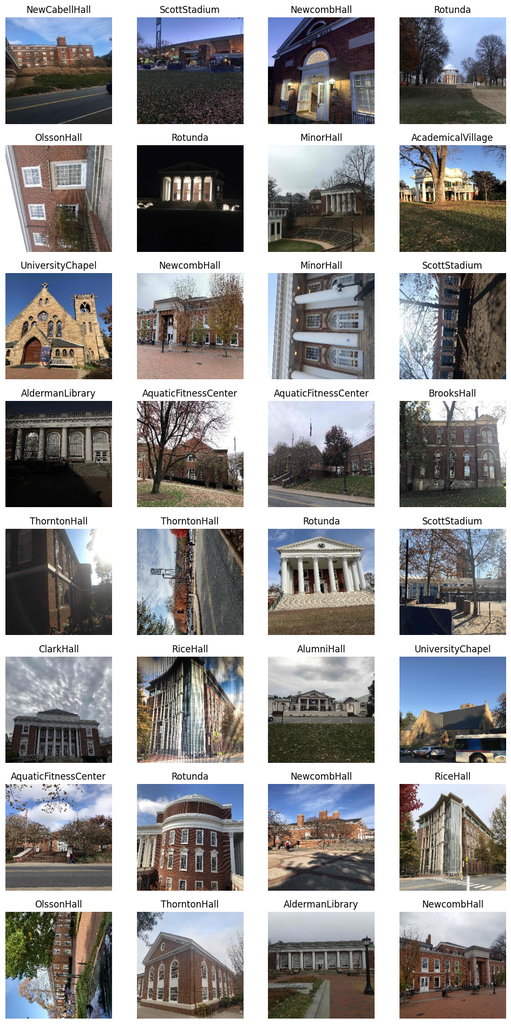

```python
from torchvision.transforms.functional import to_pil_image


# Visualize some of the train samples of one batch
# Make sure the class names always match the order of their appearances in the "files" variable
class_names = ['AcademicalVillage', 'AldermanLibrary', 'AlumniHall', 'AquaticFitnessCenter',
  'BavaroHall', 'BrooksHall', 'ClarkHall', 'MadisonHall', 'MinorHall', 'NewCabellHall',
  'NewcombHall', 'OldCabellHall', 'OlssonHall', 'RiceHall', 'Rotunda', 'ScottStadium',
  'ThorntonHall', 'UniversityChapel']
print("num classes", len(class_names))
# Rows and columns are set to fit one training batch (32)

n_rows = 8
n_cols = 4
plt.figure(figsize=(n_cols * 3, n_rows * 3))
for row in range(n_rows):
    for col in range(n_cols):
        index = n_cols * row + col
        plt.subplot(n_rows, n_cols, index + 1)
        image, target = dataset_train[index]
        plt.imshow(to_pil_image(image))
        plt.axis('off')
        plt.title(class_names[target], fontsize=12)
plt.subplots_adjust(wspace=.2, hspace=.2)

plt.show()
```

# It's your turn: Building a classifier for UVA Landmark Dataset

You may design your own architecture AND re-use any of the exising frameworks.

Best of luck!

```python
# Validation Set
val_ratio = .2
size_val = int(size_train * val_ratio)
size_train = size_train - size_val

d_train, d_val = random_split(dataset_train, [size_train, size_val], generator=Generator().manual_seed(SEED))
```

```python
# Data Loader
from torch.utils.data import DataLoader

batch_size = 32

train_loader = DataLoader(d_train, batch_size=batch_size, shuffle=True, num_workers=2, pin_memory=True)
val_loader   = DataLoader(d_val,   batch_size=batch_size, shuffle=False, num_workers=2, pin_memory=True)
test_loader  = DataLoader(dataset_test, batch_size=batch_size, shuffle=False)
```

```python
def train_model(model, train_loader, val_loader, criterion, optimizer, device, num_epochs=10):
    '''Function to perform forward pass , backward pass, and calc training metrics for specific model'''
    train_losses, train_accs = [], []
    val_losses, val_accs = [], []

    for epoch in range(num_epochs):
        # Train
        model.train()
        train_loss_sum, train_correct, train_total = 0.0, 0, 0

        for images, labels in train_loader:
            images = images.to(device)
            labels = labels.to(device).long()

            logits = model(images)
            loss = criterion(logits, labels)

            optimizer.zero_grad()
            loss.backward()
            optimizer.step()

            train_loss_sum += loss.item() * images.size(0)
            preds = logits.argmax(dim=1)
            train_correct += (preds == labels).sum().item()
            train_total += labels.size(0)

        train_loss = train_loss_sum / train_total
        train_acc = train_correct / train_total

        # Validation...
        model.eval()
        val_loss_sum, val_correct, val_total = 0.0, 0, 0

        with torch.no_grad():
            for images, labels in val_loader:
                images = images.to(device)
                labels = labels.to(device).long()

                logits = model(images)
                loss = criterion(logits, labels)

                val_loss_sum += loss.item() * images.size(0)
                preds = logits.argmax(dim=1)
                val_correct += (preds == labels).sum().item()
                val_total += labels.size(0)

        val_loss = val_loss_sum / val_total
        val_acc = val_correct / val_total

        print(
            f"Epoch {epoch+1}/{num_epochs} | "
            f"train loss {train_loss:.4f} acc {train_acc:.3f} | "
            f"val loss {val_loss:.4f} acc {val_acc:.3f}"
        )

        train_losses.append(train_loss)
        train_accs.append(train_acc)
        val_losses.append(val_loss)
        val_accs.append(val_acc)

    return train_losses, train_accs, val_losses, val_accs
```

```python
def accuracy_val_plots(train_losses, val_losses, train_accs, val_accs):
  '''Function to plot the training and validation loss and accuracy'''
  import matplotlib.pyplot as plt
  # Plot Training/Validation Loss
  plt.figure()
  plt.plot(train_losses, label="train loss")
  plt.plot(val_losses, label="val loss")
  plt.xlabel("epoch")
  plt.ylabel("loss")
  plt.legend()
  plt.show()

  # Plot Training/Validation Accuracy
  plt.figure()
  plt.plot(train_accs, label="train accuracy")
  plt.plot(val_accs, label="val accuracy")
  plt.xlabel("epoch")
  plt.ylabel("accuracy")
  plt.legend()
  plt.show()
```

```python
# Final Test Function
def final_acc_test(model, test_loader):
    '''Function to test final accuracy'''
    from sklearn.metrics import accuracy_score
    model.eval()

    all_preds = []
    all_labels = []

    with torch.no_grad():
        for X, y in test_loader:
            X = X.to(device)
            y = y.to(device)
            outputs = model(X)
            preds = torch.argmax(outputs, dim=1)
            all_preds.extend(preds.cpu().numpy())
            all_labels.extend(y.cpu().numpy())
    acc = accuracy_score(all_labels, all_preds)
    print(f"Test Accuracy: {acc:.4f}")
```

## **MODEL 1**: ALEXNET

```python
# For the first we will use alexnet
from torch.nn import Module
import torch
import torch.nn as nn
from torchvision.models import alexnet, AlexNet_Weights
from torch.utils.data import DataLoader

# Feel free to rename them!
class AlexNet(Module):
    def __init__(self, n_classes=18, pretrained=True):
        super().__init__()

        if pretrained:
            weights = AlexNet_Weights.DEFAULT
            base_model = alexnet(weights=weights)
        else:
            base_model = alexnet(weights=None)

        self.features = base_model.features
        self.avgpool = base_model.avgpool

        self.classifier = base_model.classifier
        self.classifier[6] = nn.Linear(4096, n_classes)

    def forward(self, x):
        x = self.features(x)
        x = self.avgpool(x)
        x = torch.flatten(x, 1)
        x = self.classifier(x)
        return x
```

```python
device = torch.device("cuda" if torch.cuda.is_available() else "cpu")
model = AlexNet(n_classes=len(class_names), pretrained=True).to(device)
criterion = nn.CrossEntropyLoss()
optimizer = torch.optim.Adam(model.parameters(), lr=1e-4, weight_decay=2e-3) # more weight decay to regularize
print(device)
```

```
cuda
```

```python
train_losses, train_accs, val_losses, val_accs = train_model(model, train_loader, val_loader, criterion, optimizer, device, num_epochs=10)
```

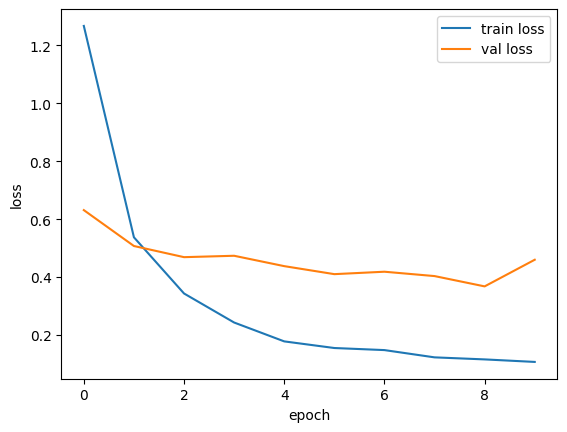

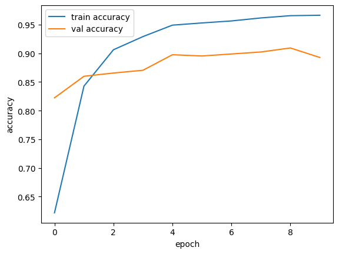

```python
accuracy_val_plots(train_losses, val_losses, train_accs, val_accs)
```

```python
# Final Accuracy Test on Testing Data
final_acc_test(model, test_loader)
```

```
Test Accuracy: 0.8908
```

AlexNet does pretty well, but after a 3-5 epochs, the model generally starts to overfit. I tried to minimize this with additional regularization methods such as dropout and weight decay, but validation accuracy did not improve much after 90%.

## Model 2: Lower level expirimentation...

```python
class Custom_CNN(nn.Module):
    def __init__(self, n_classes=18):
        super().__init__()
        self.features = nn.Sequential(
            # Layer1
            nn.Conv2d(in_channels=3, out_channels=16, kernel_size=3, padding=1),
            nn.BatchNorm2d(16), # Added batch norm
            nn.ReLU(),
            nn.MaxPool2d(kernel_size=2),
            nn.Dropout2d(p=0.0), # set dropout to zero during conv blocks
            # Layer 2
            nn.Conv2d(in_channels=16, out_channels=24, kernel_size=3, padding=1),
            nn.BatchNorm2d(24), # added batch norm
            nn.ReLU(),
            nn.MaxPool2d(kernel_size=2),
            nn.Dropout2d(p=0.0), # set dropout to zero during conv blocks
            # Layer 3
            nn.Conv2d(in_channels=24, out_channels=32, kernel_size=3, padding=1),
            nn.BatchNorm2d(32),
            nn.ReLU(),
            nn.MaxPool2d(kernel_size=2)
        )
        self.pool = nn.AdaptiveAvgPool2d(output_size=(4, 4))

        self.fcn = nn.Sequential(
            # Layer 1
            nn.Dropout(p=0.4),
            nn.Linear(in_features=512, out_features=1024),
            nn.ReLU(),
            # Layer 2
            nn.Dropout(p=0.2),
            nn.Linear(1024, 512), # added a hidden layer
            nn.ReLU(),
            # Last Layer
            nn.Linear(in_features=512, out_features=n_classes)
        )
    def forward(self, x):
        x = self.features(x)
        x = self.pool(x)
        x = torch.flatten(x, 1)
        x = self.fcn(x)
        return x
```

```python
model = Custom_CNN(n_classes=len(class_names)).to(device)
criterion = nn.CrossEntropyLoss()
optimizer = torch.optim.Adam(model.parameters(), lr=1e-3, weight_decay=3e-4)
```

```python
train_losses, train_accs, val_losses, val_accs = train_model(model, train_loader, val_loader, criterion, optimizer, device, num_epochs=50)
```

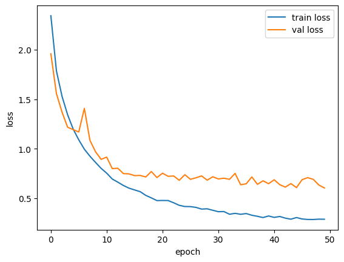

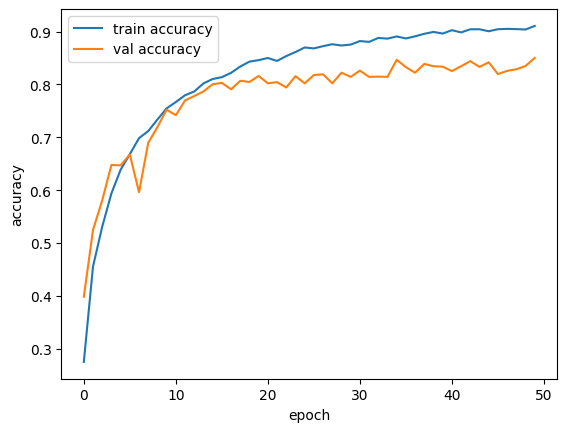

```python
# Plots
accuracy_val_plots(train_losses, val_losses, train_accs, val_accs)
```

```python
# Test Accuracy on Testing Data
final_acc_test(model, test_loader)
```

```
Test Accuracy: 0.8526
```

I built the layers of this model from "scratch" using the PyTorch nn module. Overall, I was happy with its performance, but could not get validation accuracy much better than 85% when using ADAM optimizer. I would be curious to try this approach with SGD instead of ADAM to see if the momentum helps improve the results.

## **MODEL 3**: RESNET

```python
import torch.nn as nn
from torchvision.models import resnet18, ResNet18_Weights, resnet34, ResNet34_Weights

class ResNet_Model(Module):
    def __init__(self, n_classes=18, pretrained=True):
        super().__init__()

        weights = ResNet34_Weights.DEFAULT if pretrained else None
        self.model = resnet34(weights=weights)

        in_features = self.model.fc.in_features
        self.model.fc = nn.Sequential(
            nn.Dropout(p=0),
            nn.Linear(in_features, n_classes)
        )
    def forward(self, X):
        x = self.model(X)
        return x
```

```python
model = ResNet_Model(n_classes=len(class_names)).to(device)
criterion = nn.CrossEntropyLoss()
optimizer = torch.optim.SGD(
    model.parameters(),
    lr=1e-2,
    momentum=.9,
    weight_decay=1e-4 # could also try something larger, like 5e-4 or 1e-3
    )
```

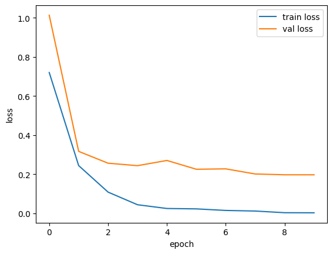

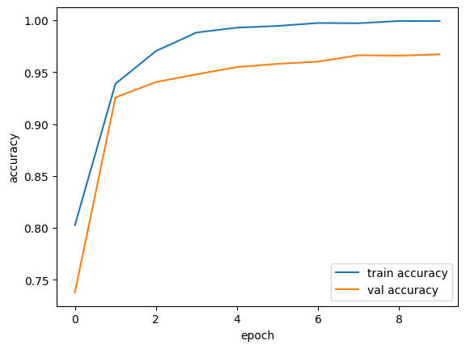

```python
# Train Model
train_losses, train_accs, val_losses, val_accs = train_model(model, train_loader, val_loader, criterion, optimizer, device, num_epochs=10)
# Plot
accuracy_val_plots(train_losses, val_losses, train_accs, val_accs)
```

```python
# Final Test Accuracy using Testing Data
final_acc_test(model, test_loader)
```

```
Test Accuracy: 0.9695
```